# Part 2 - Training some Binary Classifiers using Scikit Learn

## Identifying struggling customers so we can provide more accommodating payment plans

This part is about training models that are able to predict which customers are more likely to struggle, so we can accommodate those cases better.

## 🚨 This is the continuation of the previous notebook. If this is the first file you are opening during correctiong, considering reviewing the readme file to understand how this project is structured.

In the previous files:

- ✅ we have prepared our datasets: we have split our data into 4 different datasets for train/hp_tuning/val/test
- ✅ we have explored our data to get a general understanding of what it looks like
- ✅ we have found ways to engineer new features that helped our predictive power.
- ✅ we have used tools from Inferential Statistics and Information Theory to help us understand which features are more likely to contribute to our models
- ✅ we have automated our data cleaning processes and stored fresh/cleaned data on disk to save us valuable time

In this file:

- We will try out a few models (simple binary classifiers and ensembles) and compare their performances.
- We will use Optuna to orchestrate hyperparameter tuning studies and trials
- We will create some custom utilities to boost optuna so it can run highly concurrently (using multiprocessing instead of the default multithreading)
- We will explore training models using imbalanced datasets (spoiler alert: we don't expect them to perform too well)

This notebook begins with the same boilerplate as the other ones (imports, basic feature toggles, etc...)

## Imports and initial setup

```python
import ipywidgets as widgets
from IPython.display import display, Markdown, Image, clear_output, HTML, IFrame
import matplotlib.pyplot as plt
from matplotlib.patches import Rectangle
from mpl_toolkits.mplot3d import Axes3D
import itertools

import warnings

warnings.filterwarnings("ignore", category=DeprecationWarning)
warnings.filterwarnings("ignore", category=FutureWarning)
warnings.filterwarnings("ignore")

import numpy as np
import pandas as pd
import polars as pl
import sqlite3
import seaborn as sns
from scipy import stats
from scipy.stats import chi2_contingency
import missingno as msno
import klib
import warnings

import statsmodels.api as sm

from random import random, seed
import sqlite3 as lite
import logging
import warnings
import ydata_profiling
import iplantuml
import xml.dom.minidom

from sklearn.feature_selection import SelectKBest, f_regression
from sklearn.metrics import (
    ConfusionMatrixDisplay,
    precision_recall_curve,
    accuracy_score,
    recall_score,
    precision_score,
    make_scorer,
    confusion_matrix,
    f1_score,
    PrecisionRecallDisplay,
    roc_auc_score,
)

from autofeatselect import CorrelationCalculator, FeatureSelector, AutoFeatureSelect

from sklearn.preprocessing import RobustScaler, FunctionTransformer
from sklearn.impute import SimpleImputer
from sklearn.decomposition import PCA
from sklearn.linear_model import LinearRegression, LogisticRegression
from sklearn.model_selection import GridSearchCV
from sklearn.tree import plot_tree
from sklearn.metrics import make_scorer, confusion_matrix, PrecisionRecallDisplay
from sklearn.pipeline import Pipeline
from sklearn.impute import KNNImputer
from sklearn.pipeline import make_pipeline
from sklearn.compose import ColumnTransformer
from sklearn.base import BaseEstimator, TransformerMixin
from sklearn.base import clone as clone_pipeline
from sklearn.experimental import enable_iterative_imputer
from sklearn.impute import IterativeImputer
from sklearn.neighbors import NearestNeighbors

from sklearn.ensemble import RandomForestClassifier, ExtraTreesClassifier
from sklearn.linear_model import LogisticRegression
import xgboost
from xgboost import XGBClassifier
from sklearn.model_selection import GridSearchCV
from sklearn.svm import SVC
import shap
import yellowbrick

from imblearn.under_sampling import RandomUnderSampler
import joblib
import pickle

import os
from os import path

from utils import *
from utils import __

from autofeat import AutoFeatRegressor as AFR
from sklearn.model_selection import train_test_split as sklearn_train_test_split
from sklearn.exceptions import DataConversionWarning
import sweetviz as sv

import featuretools as ft
import woodwork as ww
import json
import subprocess

import category_encoders as ce

warnings.filterwarnings("ignore", category=DeprecationWarning)
warnings.filterwarnings("ignore", category=FutureWarning)
warnings.filterwarnings("ignore")
seed(100)
pd.options.display.max_rows = 100
pd.options.display.max_colwidth = 50
util.check("done")
```

```
loading utils modules... ✅ completed
configuring autoreload... ✅ completed
✅
```

```python
%reload_ext credit_clean
%reload_ext credit_utils

import credit_clean
import credit_utils
```

Let's use `black` to auto-format all our cells so they adhere to PEP8

```python
import lab_black

%reload_ext lab_black
util.patch_nb_black()
# fmt: off
# fmt: on
```

```python
from sklearn import set_config

set_config(transform_output="pandas")
```

```python
sns.set_theme(context="notebook", style="whitegrid")

moonstone = "#62b6cb"
moonstone_rgb = handy_utils.hex_to_rgb(moonstone)
moonstone_rgb_n = np.array(moonstone_rgb) / 255
```

```python
logger = util.configure_logging(jupyterlab_level=logging.WARN, file_level=logging.DEBUG)

warnings.filterwarnings("ignore", category=FutureWarning)

# import warnings
# warnings.filterwarnings('error', category=pd.errors.DtypeWarning)
```

```python
def ding(title="Ding!", message="Task completed"):
    """
    this method only works on linux
    """
    for i in range(2):
        !notify-send '{title}' '{message}'
```

## Feature Toggles

Let's also create a simple feature toggle that we can use to skip expensive operations during notebook work (to save myself some time!)

Set it to true if you want to run absolutely everything. Set to false to skip optional steps/exploratory work.

```python
def run_entire_notebook(filename: str = None):
    run_all = False
    if not run_all:
        print("skipping optional operation")
        fullpath = f"cached/printouts/{filename}.txt"
        if filename is not None and os.path.exists(fullpath):
            print("==== 🗃️ printing cached output ====")
            with open(fullpath) as f:
                print(f.read())
    return run_all
```

We will also create a small settings file to store all of the tweaks/configs we might need during production (TRAIN/FIT/DEPLOYED MODEL) so we can guarantee that we rely on this instead of having to remember/risking misconfiguring

```python
prod_settings = ProdSettings("prod/settings.json")
```

# Time to train some predictive models!

Let's recall a few important facts that we learned, so far:

- Training Dataset has 200k loans (+ their associated tables)
- Dataset imbalance is 12-to-1
- The dataset seems to have similar ratios of NA for most features (the imbalance is real and cannot be reduced)
- Undersampling seems like our safest approach, but we won't discard oversampling, just yet.

```python
target_classes = 2
imbalance_ratio = 12
print(f"{(215_000 // imbalance_ratio) * target_classes:,} rows (assuming 50% split)")
```

```
35,832 rows (assuming 50% split)
```

Our first estimation (simple and optimistic) shows a "reasonable enough" dataset, even if we used undersampling.

The actual number will definitely be smaller. We need to be careful with the number of features, we should aim for a long-and-narrow dataset. If we cannot make it longer, the only way to increase the ratio will be to use fewer columns.

```python
def load_table(tablename: str, db_connection: sqlite3.Connection) -> pd.DataFrame:
    return auto_pandas.normalize_columns(
        pd.read_sql(f"SELECT * FROM {tablename};", db_connection)
    )
```

Let's remember how we split our data:

- Training: 70%
- Test: 10%
- Hyperparameter Tuning: 10%
- Validation: 10%

So far, we have verified that the datasets have been shuffled similarly and that they have been split properly using stratification (similar imbalances, similar ratios and proportions...) and that there is no overlap between any of them and partitioning is atomic (all Database PKs are unique and all data belonging to customer X is in one of the database, only)

# Hyperparameter Tuning

For Hyperparameter tuning, we will use optuna (as it has worked well in past projects) and we have developed a set of custom functions that will use multithreading-multiprocessing to increase the speed at which we can train/tune our models.

We use custom multi-processing concurrent code instead of the built-in multithreading because multithreading does not scale up well for CPU-bound tasks, due to the shared [Python Global Interpreter Lock](https://realpython.com/python-gil/)

**Optuna Docs**

> `n_jobs` allows parallelization using threading and may suffer from Python's GIL. It is recommended to use process-based parallelization if func is CPU bound.

For this tuning, we have created a library that uses Kfold cross-validation for all tasks that require validation (eg. We are also **planning on using K-Fold CrossValidation** when traning and assessing our model's performance).

**This mean we will no longer need the validation split.**

Since that split won't be needed, we would like to use its data to increase the size of our hyperparam split because it might be a bit on the smaller side (cleaning was quite good, dropping around ~20% of data, but if we want to use a balanced dataset, the 12-to-1 ration will be problematic).

We expect that this decision (KFold CV) for *hyper parameter tuning* and *model training and evaluation* will allow us to have a bit more data HP tuning and result in some better performance.

It does mean it will run a bit slower as we will do multiple splits/passes... but that's the cost of having little data... we must use the data we have, smartly... while taking precautions to not accidentally fool ourselves!

```python
def xy_clean_save(X: pd.DataFrame, y: pd.Series, name: str):
    X.to_parquet(f"dataset/clean/{name}_X.parquet", compression="gzip")
    pd.DataFrame(y).to_parquet(f"dataset/clean/{name}_y.parquet", compression="gzip")


def xy_read(name: str) -> tuple[pd.DataFrame, pd.Series]:
    X = pd.read_parquet(f"dataset/clean/{name}_X.parquet")
    y = pd.read_parquet(f"dataset/clean/{name}_y.parquet")["target"]
    return X, y
```

```python
X_hyper1, y_hyper1 = xy_read("hyper")
```

```python
X_hyper2, y_hyper2 = xy_read("val")
```

```python
X_hyper = pd.concat([X_hyper1, X_hyper2])
y_hyper = pd.concat([y_hyper1, y_hyper2])
```

These two datasets were already shuffled during the split step, shuffling it further after merging them did not contribute to better performance.

```python
candidate_providers = {
    "xgbclassifier": optuna_utils.XgbClassifierCandidateProvider(),
    "logreg": optuna_utils.LogisticRegressionCandidateProvider(),
    "random_forest": optuna_utils.RandomForestCandidateProvider(),
    "extra_trees": optuna_utils.ExtRaTreesCandidateProvider(),
    "ensemble_voting_1": optuna_utils.VotingCandidateProvider(5),
}
```

```python
def tune_all_models(X_, y_):
    X_, y_ = eda_utils.balance_xy(X_, y_)
    for model_name, candidate_provider in candidate_providers.items():
        study_name = f"model_{model_name}"
        optuna_utils.create_optuna_study(
            study_name=study_name, allow_resume=True, direction="maximize"
        )
        objective = optuna_utils.build_objective_function(
            candidate_provider,
            X_,
            y_,
            scoring_function=f1_score,
        )
        optuna_utils.parallelize_optuna(
            study_name, n_processes=4, trials_per_process=5, objective=objective
        )
        display(optuna_utils.get_best_model(study_name))


if run_entire_notebook():
    tune_all_models(X_hyper, y_hyper)
```

```
skipping optional operation
```

```python
for study_name in candidate_providers.keys():
    display(optuna_utils.get_best_model(f"model_{study_name}"))
```

```
XGBClassifier(base_score=None, booster=None, colsample_bylevel=None,
              colsample_bynode=None, colsample_bytree=0.3017066331755987,
              gamma=0.010464585053241961, gpu_id=None, importance_type='gain',
              interaction_constraints=None, learning_rate=0.010998589853339952,
              max_delta_step=None, max_depth=4, min_child_weight=9, missing=nan,
              monotone_constraints=None, n_estimators=800, n_jobs=16,
              num_parallel_tree=None, random_state=42,
              reg_alpha=0.0002096718374236909, reg_lambda=None,
              scale_pos_weight=None, subsample=0.6561983312530707,
              tree_method=None, validate_parameters=None, verbosity=None)
```

```
LogisticRegression(C=0.0167357214900526, fit_intercept=False,
                   l1_ratio=0.2885210428096302, max_iter=9650, n_jobs=16,
                   penalty='elasticnet', random_state=42, solver='saga')
```

```
RandomForestClassifier(max_depth=31, max_features='log2', min_samples_leaf=10,
                       min_samples_split=3, n_estimators=680, n_jobs=16,
                       random_state=42)
```

```
ExtraTreesClassifier(criterion='entropy', max_depth=23, max_features='log2',
                     min_samples_split=7, n_estimators=650, n_jobs=16,
                     random_state=42)
```

```
VotingClassifier(estimators=[('xgbc1',
                              XGBClassifier(base_score=None, booster=None,
                                            colsample_bylevel=None,
                                            colsample_bynode=None,
                                            colsample_bytree=0.42618559558532837,
                                            gamma=0.0010719168310100332,
                                            gpu_id=None, importance_type='gain',
                                            interaction_constraints=None,
                                            learning_rate=0.017951025225957762,
                                            max_delta_step=None, max_depth=4,
                                            min_child_weight=6, missing=n...
                                            subsample=0.34664992828940194,
                                            tree_method=None,
                                            validate_parameters=None,
                                            verbosity=None)),
                             ('rf2',
                              RandomForestClassifier(max_depth=21,
                                                     max_features='log2',
                                                     min_samples_split=5,
                                                     n_estimators=13)),
                             ('rf1',
                              RandomForestClassifier(max_depth=23,
                                                     max_features='auto',
                                                     min_samples_leaf=5,
                                                     min_samples_split=5,
                                                     n_estimators=812))],
                 n_jobs=16, voting='soft', weights=[1, 1, 1, 1, 1])
```

```python
studies = {}
for candidate in candidate_providers.keys():
    study_name = f"model_{candidate}"
    filename = f"optuna_studies/study_{study_name}.db"
    if path.exists(filename):
        print(filename, "ok ✅")
        studies[study_name] = optuna_utils.get_study(study_name=study_name)
    else:
        print(filename, "skipping...")
```

```
optuna_studies/study_model_xgbclassifier.db ok ✅
optuna_studies/study_model_logreg.db ok ✅
optuna_studies/study_model_random_forest.db ok ✅
optuna_studies/study_model_extra_trees.db ok ✅
optuna_studies/study_model_ensemble_voting_1.db ok ✅
```

```
Loading from cache [./cached/charts/confusion_matrices_unseen_data_optimizing_custom_score.png]
```

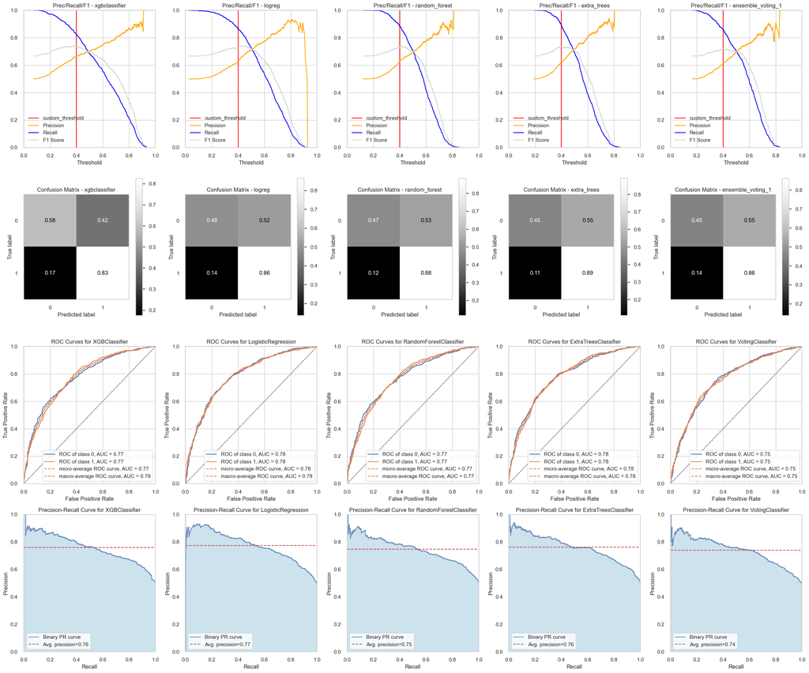

```python
@cached_chart()
def confusion_matrices_unseen_data_optimizing_custom_score(X, y):
    proba_threshold = 0.40

    cols = len(candidate_providers)
    fig, ax = plt.subplots(4, len(candidate_providers), figsize=(6 * 4, 4 * cols))

    for (c, candidate) in enumerate(candidate_providers.keys()):
        cax_thr = ax[0, c]
        cax_conf = ax[1, c]
        cax_roc = ax[2, c]
        cax_pr = ax[3, c]

        study_name = f"model_{candidate}"
        print(f"loading hyperparams for model {study_name = }")

        X = X.sample(frac=1)
        y = y.loc[X.index]
        X, y = eda_utils.balance_xy(X, y)

        (
            X_train_split,
            X_test_split,
            y_train_split,
            y_test_split,
        ) = sklearn_train_test_split(X, y, test_size=0.2, random_state=42, stratify=y)

        best_model = optuna_utils.get_best_model(study_name)
        best_model.fit(X_train_split, y_train_split)

        chart_utils.plot_precision_recall_f1_scores(
            fitted_probab_model=best_model,
            X=X_test_split,
            y_true=y_test_split,
            threshold=proba_threshold,
            ax=cax_thr,
            title=f"Prec/Recall/F1 - {candidate}",
        )

        y_pred_proba = best_model.predict_proba(X_test_split)
        y_pred = y_pred_proba[:, 1] > proba_threshold

        ConfusionMatrixDisplay.from_predictions(
            y_test_split,
            y_pred,
            labels=[0, 1],
            display_labels=[0, 1],
            normalize="true",
            ax=cax_conf,
            cmap="Greys_r",
        )
        cax_conf.grid(False)
        cax_conf.set_title(f"Confusion Matrix - {candidate}")

        cm = yellowbrick.classifier.ROCAUC(best_model, is_fitted=True, ax=cax_roc)
        cm.fit(X_train_split, y_train_split)
        cm.score(X_test_split, y_test_split)
        cm.finalize()

        cm = yellowbrick.classifier.PrecisionRecallCurve(
            best_model, is_fitted=True, ax=cax_pr
        )
        cm.fit(X_train_split, y_train_split)
        cm.score(X_test_split, y_test_split)
        cm.finalize()

    plt.tight_layout()
    return fig


confusion_matrices_unseen_data_optimizing_custom_score(X_hyper, y_hyper)
```

```python
def calculate_accuracies(X, y):
    proba_threshold = 0.40

    for (c, candidate) in enumerate(candidate_providers.keys()):
        study_name = f"model_{candidate}"

        X = X.sample(frac=1)
        y = y.loc[X.index]
        X, y = eda_utils.balance_xy(X, y)

        (
            X_train_split,
            X_test_split,
            y_train_split,
            y_test_split,
        ) = sklearn_train_test_split(X, y, test_size=0.2, random_state=42, stratify=y)

        best_model = optuna_utils.get_best_model(study_name)
        display(best_model)
        best_model.fit(X_train_split, y_train_split)

        y_pred_proba = best_model.predict_proba(X_test_split)
        y_pred = y_pred_proba[:, 1] > proba_threshold

        print(candidate, accuracy_score(y_test_split, y_pred))


calculate_accuracies(X_hyper, y_hyper)
```

```
XGBClassifier(base_score=None, booster=None, colsample_bylevel=None,
              colsample_bynode=None, colsample_bytree=0.3017066331755987,
              gamma=0.010464585053241961, gpu_id=None, importance_type='gain',
              interaction_constraints=None, learning_rate=0.010998589853339952,
              max_delta_step=None, max_depth=4, min_child_weight=9, missing=nan,
              monotone_constraints=None, n_estimators=800, n_jobs=16,
              num_parallel_tree=None, random_state=42,
              reg_alpha=0.0002096718374236909, reg_lambda=None,
              scale_pos_weight=None, subsample=0.6561983312530707,
              tree_method=None, validate_parameters=None, verbosity=None)
```

```
xgbclassifier 0.6771812080536913
```

```
LogisticRegression(C=0.0167357214900526, fit_intercept=False,
                   l1_ratio=0.2885210428096302, max_iter=9650, n_jobs=16,
                   penalty='elasticnet', random_state=42, solver='saga')
```

```
logreg 0.6181208053691275
```

```
RandomForestClassifier(max_depth=31, max_features='log2', min_samples_leaf=10,
                       min_samples_split=3, n_estimators=680, n_jobs=16,
                       random_state=42)
```

```
random_forest 0.6523489932885906
```

```
ExtraTreesClassifier(criterion='entropy', max_depth=23, max_features='log2',
                     min_samples_split=7, n_estimators=650, n_jobs=16,
                     random_state=42)
```

```
extra_trees 0.648993288590604
```

```
VotingClassifier(estimators=[('xgbc1',
                              XGBClassifier(base_score=None, booster=None,
                                            colsample_bylevel=None,
                                            colsample_bynode=None,
                                            colsample_bytree=0.42618559558532837,
                                            gamma=0.0010719168310100332,
                                            gpu_id=None, importance_type='gain',
                                            interaction_constraints=None,
                                            learning_rate=0.017951025225957762,
                                            max_delta_step=None, max_depth=4,
                                            min_child_weight=6, missing=n...
                                            subsample=0.34664992828940194,
                                            tree_method=None,
                                            validate_parameters=None,
                                            verbosity=None)),
                             ('rf2',
                              RandomForestClassifier(max_depth=21,
                                                     max_features='log2',
                                                     min_samples_split=5,
                                                     n_estimators=13)),
                             ('rf1',
                              RandomForestClassifier(max_depth=23,
                                                     max_features='auto',
                                                     min_samples_leaf=5,
                                                     min_samples_split=5,
                                                     n_estimators=812))],
                 n_jobs=16, voting='soft', weights=[1, 1, 1, 1, 1])
```

```
ensemble_voting_1 0.6711409395973155
```

## Best performing model

The relative performance of the models has changed from one run to the next, but overall XGBoost and the Ensemble model have been the ones that have performed more consistently.

In this specific run XGBoost is performing better, while the other candidates are able to offer slightly more recall but at a huge loss in precision.

We will likely pick XGBoostClassifier for our final model (once we test how it performs on Training/Test split)

### Regarding business metrics and acceptance criteria

The ratio of recall ~= 80% and precision ~60% seems like a good balance of catching as many cases of customers who will struggle, without unnecessarily flagging too many cases that would not struggle (false positives).

## Logistic Regression without manually balancing our data

Seeing that LogisticRegressionClassifier performs almost as well as (or better than!) our more complex models (XGBC and a Custom Ensemble model we created pseudo-randomly with, let's try one last model before we call off this part of the project: Let's try using the same model but with the entire dataset (instead of balancing it manually). Logistic Regression is robuts against most imbalances (as long as they are not extreme).

Nope.. running Logistic Regression on an unbalanced dataset got worse performance than on an artificially balanced one. Even though Logistic Regression is robuts to class imbalances, it is still somewhat affected by them.

When imbalance was 12 to 1: f1_score = 0.05 (original imbalance) When imbalance was 3 to 1: f1_score = 0.53 When imbalance was 2 to 1: f1_score = 0.61

So we decided to drop the model and only look at the ones trained on the balanced dataset.

### Regarding Ensemble Models

For now, they are created and configured randomly using semi-random configurations (types of the inner estimators, and the base parameters for each of them), but this could be refined further given more time/resources. The same methodology could be used for other ensemble types (Voting/Bagging/Stacking...).

Part of the challenge for this optimization was around creating some custom code to improve optuna's speed so it fully uses the system's resources.

Among the changes made (check `optuna_utils.py` for more info), we created code for:

- using multiprocessing to improve concurrency and throughput (instead of the default multi-threading which is constrained by Python's GIL)
- tapping into optuna's early pruning system by providing intermediate performance scores (allowing us to save computing resources and kill trials early if they do not show promising results)
- using a custom abstract class `CandidateProvider` which breaches the gap between "what parameters a model would required" (to be tuned), and what optuna can provide/track for us (parameter ranges, specific values for a given trial in a study, etc..)
- various implementations of `CandidateProvider` for most common models:
  - Classifiers
    - `XgbClassifierCandidateProvider()`
    - `LogisticRegressionCandidateProvider()`
    - `RandomForestCandidateProvider()`
    - `ExtRaTreesCandidateProvider()`
    - `SVCCandidateProvider()`
    - `KNeighborsCandidateProvider()`
    - `GaussianNBCandidateProvider()`
    - `DecisionTreeCandidateProvider()`
  - EnsembleModels
    - `VotingCandidateProvider()`
    - `StackingCandidateProvider()`
    - `BaggingCandidateProvider()`
  - Regressors
    - `XgbRegressorCandidateProvider()`
    - `RidgeRegressorCandidateProvider()`
    - `LassoRegressorCandidateProvider()`
    - `ElasticNetRegressorCandidateProvider()`
    - `RandomForestRegressorCandidateProvider()`
    - `ExtRaTreesRegressorCandidateProvider()`

Some of these were developed in previous projects (and are unused in this project).

Ensemble Model Candidate Providers have been created for this project to try encoding the entire configuration of the model into custom user attributes in optuna DB format,

```python
@run
def optuna_params_example_params():
    conn = sqlite3.connect("optuna_studies/study_model_ensemble_voting_1.db")
    df = (
        pd.read_sql("SELECT * FROM trial_params WHERE trial_id = 1", conn)
        .set_index("param_id")
        .drop(columns="trial_id")
    )

    with pd.option_context("display.max_colwidth", 3):
        display(df)
```

| param_id | param_name | param_value | distribution_json |
| --- | --- | --- | --- |
| 35 | __voting | 0.000000 | {"name": "CategoricalDistribution", "attributes": {"choices": ["soft"]}} |
| 10 | ex1__criterion | 1.000000 | {"name": "CategoricalDistribution", "attributes": {"choices": ["gini", "entropy"]}} |
| 11 | ex1__max_depth | 12.000000 | {"name": "IntDistribution", "attributes": {"log": false, "step": 1, "low": 2, "high": 32}} |
| 14 | ex1__max_features | 2.000000 | {"name": "CategoricalDistribution", "attributes": {"choices": ["auto", "sqrt", "log2"]}} |
| 13 | ex1__min_samples_leaf | 8.000000 | {"name": "IntDistribution", "attributes": {"log": false, "step": 1, "low": 1, "high": 10}} |
| 12 | ex1__min_samples_split | 5.000000 | {"name": "IntDistribution", "attributes": {"log": false, "step": 1, "low": 2, "high": 10}} |
| 9 | ex1__n_estimators | 50.000000 | {"name": "IntDistribution", "attributes": {"log": false, "step": 50, "low": 50, "high": 1000}} |
| 30 | rf1__criterion | 0.000000 | {"name": "CategoricalDistribution", "attributes": {"choices": ["gini", "entropy"]}} |
| 31 | rf1__max_depth | 17.000000 | {"name": "IntDistribution", "attributes": {"log": false, "step": 1, "low": 2, "high": 32}} |
| 34 | rf1__max_features | 1.000000 | {"name": "CategoricalDistribution", "attributes": {"choices": ["auto", "sqrt", "log2"]}} |
| 33 | rf1__min_samples_leaf | 5.000000 | {"name": "IntDistribution", "attributes": {"log": false, "step": 1, "low": 1, "high": 10}} |
| 32 | rf1__min_samples_split | 10.000000 | {"name": "IntDistribution", "attributes": {"log": false, "step": 1, "low": 2, "high": 10}} |
| 29 | rf1__n_estimators | 576.000000 | {"name": "IntDistribution", "attributes": {"log": false, "step": 1, "low": 10, "high": 1000}} |
| 24 | rf2__criterion | 0.000000 | {"name": "CategoricalDistribution", "attributes": {"choices": ["gini", "entropy"]}} |
| 25 | rf2__max_depth | 11.000000 | {"name": "IntDistribution", "attributes": {"log": false, "step": 1, "low": 2, "high": 32}} |
| 28 | rf2__max_features | 1.000000 | {"name": "CategoricalDistribution", "attributes": {"choices": ["auto", "sqrt", "log2"]}} |
| 27 | rf2__min_samples_leaf | 8.000000 | {"name": "IntDistribution", "attributes": {"log": false, "step": 1, "low": 1, "high": 10}} |
| 26 | rf2__min_samples_split | 10.000000 | {"name": "IntDistribution", "attributes": {"log": false, "step": 1, "low": 2, "high": 10}} |
| 23 | rf2__n_estimators | 561.000000 | {"name": "IntDistribution", "attributes": {"log": false, "step": 1, "low": 10, "high": 1000}} |
| 5 | xgbc1__colsample_bytree | 0.676245 | {"name": "FloatDistribution", "attributes": {"step": null, "low": 0.3, "high": 1.0, "log": false}} |
| 7 | xgbc1__gamma | 0.717122 | {"name": "FloatDistribution", "attributes": {"step": null, "low": 1e-06, "high": 1.0, "log": true}} |
| 3 | xgbc1__learning_rate | 0.335955 | {"name": "FloatDistribution", "attributes": {"step": null, "low": 0.001, "high": 1.0, "log": true}} |
| 2 | xgbc1__max_depth | 9.000000 | {"name": "IntDistribution", "attributes": {"log": false, "step": 1, "low": 2, "high": 10}} |
| 6 | xgbc1__min_child_weight | 10.000000 | {"name": "IntDistribution", "attributes": {"log": false, "step": 1, "low": 1, "high": 10}} |
| 1 | xgbc1__n_estimators | 720.000000 | {"name": "IntDistribution", "attributes": {"log": false, "step": 10, "low": 50, "high": 1000}} |
| 8 | xgbc1__reg_alpha | 0.000003 | {"name": "FloatDistribution", "attributes": {"step": null, "low": 1e-06, "high": 1.0, "log": true}} |
| 4 | xgbc1__subsample | 0.789859 | {"name": "FloatDistribution", "attributes": {"step": null, "low": 0.3, "high": 1.0, "log": false}} |
| 19 | xgbc2__colsample_bytree | 0.764718 | {"name": "FloatDistribution", "attributes": {"step": null, "low": 0.3, "high": 1.0, "log": false}} |
| 21 | xgbc2__gamma | 0.000352 | {"name": "FloatDistribution", "attributes": {"step": null, "low": 1e-06, "high": 1.0, "log": true}} |
| 17 | xgbc2__learning_rate | 0.004137 | {"name": "FloatDistribution", "attributes": {"step": null, "low": 0.001, "high": 1.0, "log": true}} |
| 16 | xgbc2__max_depth | 7.000000 | {"name": "IntDistribution", "attributes": {"log": false, "step": 1, "low": 2, "high": 10}} |
| 20 | xgbc2__min_child_weight | 7.000000 | {"name": "IntDistribution", "attributes": {"log": false, "step": 1, "low": 1, "high": 10}} |
| 15 | xgbc2__n_estimators | 580.000000 | {"name": "IntDistribution", "attributes": {"log": false, "step": 10, "low": 50, "high": 1000}} |
| 22 | xgbc2__reg_alpha | 0.000001 | {"name": "FloatDistribution", "attributes": {"step": null, "low": 1e-06, "high": 1.0, "log": true}} |
| 18 | xgbc2__subsample | 0.687519 | {"name": "FloatDistribution", "attributes": {"step": null, "low": 0.3, "high": 1.0, "log": false}} |

This has been useful for debugging purposes.

In previous projects we used to use these to re-create the model from the database when we needed to train it and predict... Unfortunately, with ensemble models, it proved unnecessarily cumbersome, so our code was changed to use joblib (which is way easier to handle).

```python
@run
@cached_dataframe()
def optuna_params_example_model():
    conn = sqlite3.connect("optuna_studies/study_model_ensemble_voting_1.db")
    return pd.read_sql(
        "SELECT * FROM trial_user_attributes WHERE key = 'serialized_model' LIMIT 5",
        conn,
    ).set_index("trial_user_attribute_id")
```

```
Loading from cache [./cached/df/optuna_params_example_model.parquet]
```

| trial_user_attribute_id | trial_id | key | value_json |
| --- | --- | --- | --- |
| 1 | 1 | serialized_model | "eF6lVctvG0UYT5w4rt08bPJoUp6FpKRFspQUCSWoccjLp... |
| 2 | 2 | serialized_model | "eF6lVUuIHEUY3sfsjjPuZmfcRzZqfMRsslEY2MkS3WgyM... |
| 3 | 3 | serialized_model | "eF6llctvG0Ucx/NwbGySxiGPpkB5lKZNQbIUNyqk0LrKo... |
| 4 | 4 | serialized_model | "eF6lVV9oHEUYT3KXu9w1aS/mT6ONtkqrqcJB0iC0klzNn... |
| 5 | 5 | serialized_model | "eF6lVUtsG0UYjhMnjk3SOM+mvEEtpCAMSREihcSQR11YM... |

This proved a lot simpler and it allowed us to clean part of the re-creation logic we had used in previous projects.

# Next steps

In this notebook we have used optuna to perform hyperparameter tuning. Optuna uses a sampler that relies on a Tree-structured Parzen Estimator algorithm to select optimal parameters to try out. This TPE algorithm relies on Gaussian Mixture Models under the hood to choose optimal parameters.

Based on what we have seen, optuna has worked quite well and generally achieves close to asymptotical scores, with minimal improvements for long runs.

In the next notebook, we will train our chosen model and evaluate its performance on unseen data (similar to what we have done so far, but at a larger scale: using the entire train/test datasets created solely for this purpose).